# GEOG 6000 Lab Plotting with ggplot2

We can also split the data into facets, which will automatically split the data when adding trend lines:

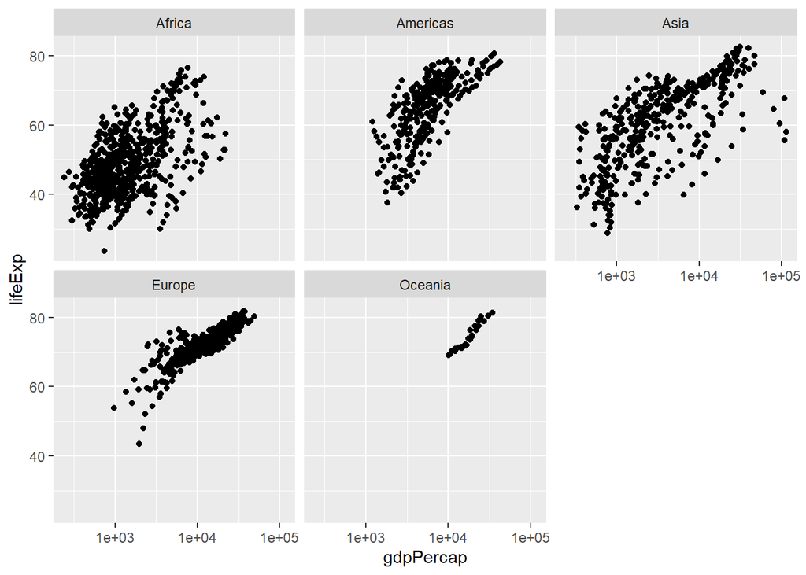

```r
myplot <- ggplot(gapdata, aes(x = gdpPercap, y = lifeExp)) + scale_x_log10()

myplot +
  geom_point() +
  facet_wrap(~ continent)
```

And we can add a linear fit by continent:

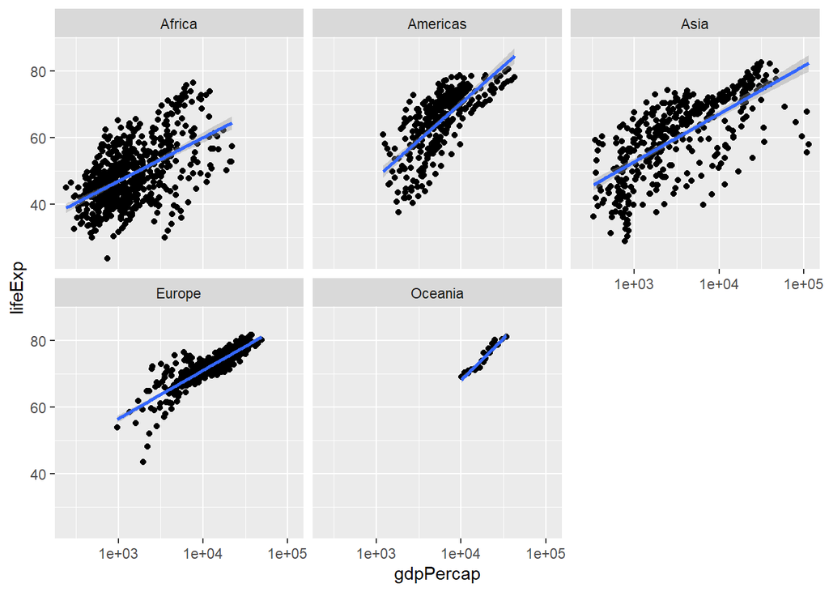

```r
myplot +
  geom_point() +
  facet_wrap(~ continent) +
  geom_smooth(method = 'lm')
```

Finally, we can facet by both continent and year by using `facet_grid()`:

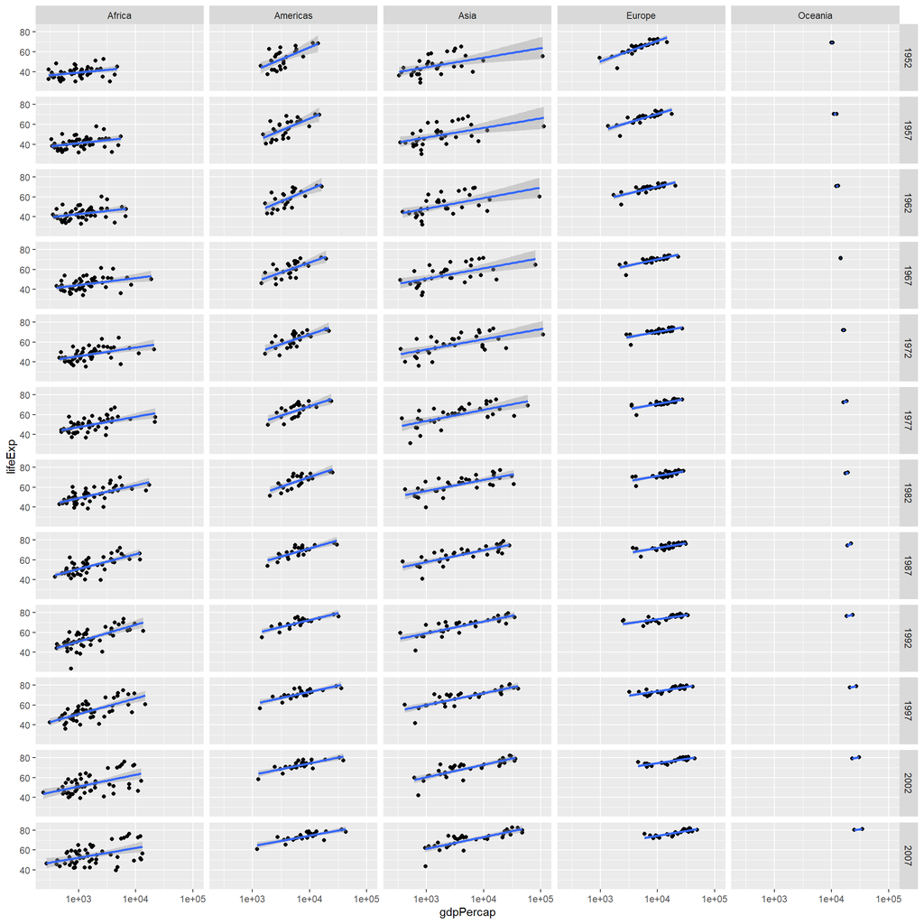

```r
myplot +
  geom_point() +
  facet_grid(year ~ continent) +
  geom_smooth(method = 'lm')
```

Line plots are a good method for displaying data over time. We’ll make a spaghetti diagram of the change in life expectancy for each country, broken out by continent. To do this, we tell the `geom_line()` function to use groupings based on the country name for each line:

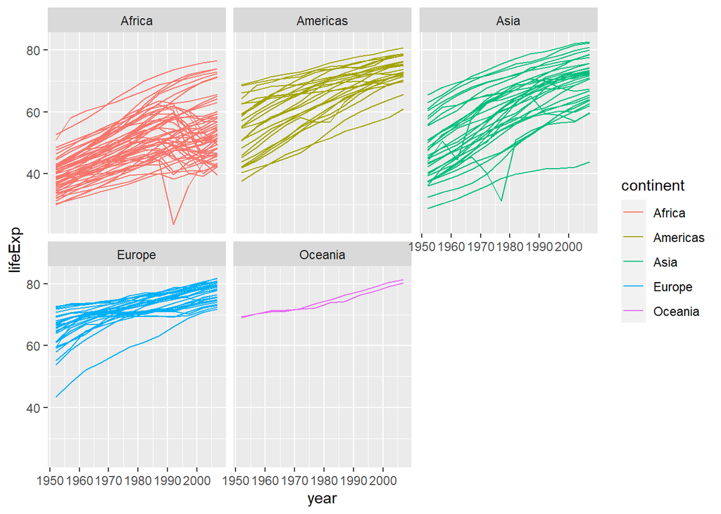

```r
myplot <- ggplot(gapdata, aes(x = year, y = lifeExp))

myplot +
  facet_wrap(~ continent) +
  geom_line(aes(group = country, color = continent))
```

We can also look at different subsets of the data using a couple of different methods. Both of these examples used the R function `subset()` to extract just part of a dataframe; the first just extracts a single country, the second all countries from a list:

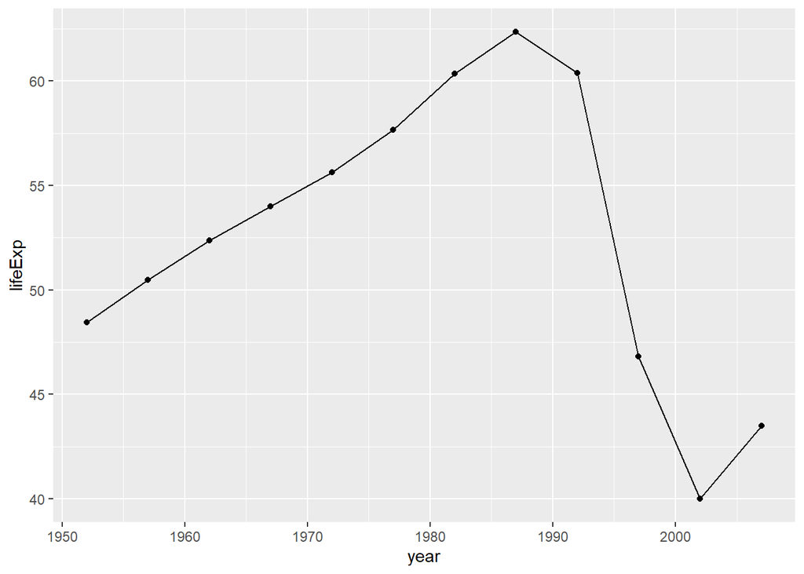

```r
ggplot(subset(gapdata, country == "Zimbabwe"),
       aes(x = year, y = lifeExp)) +
  geom_line() +
  geom_point()
```

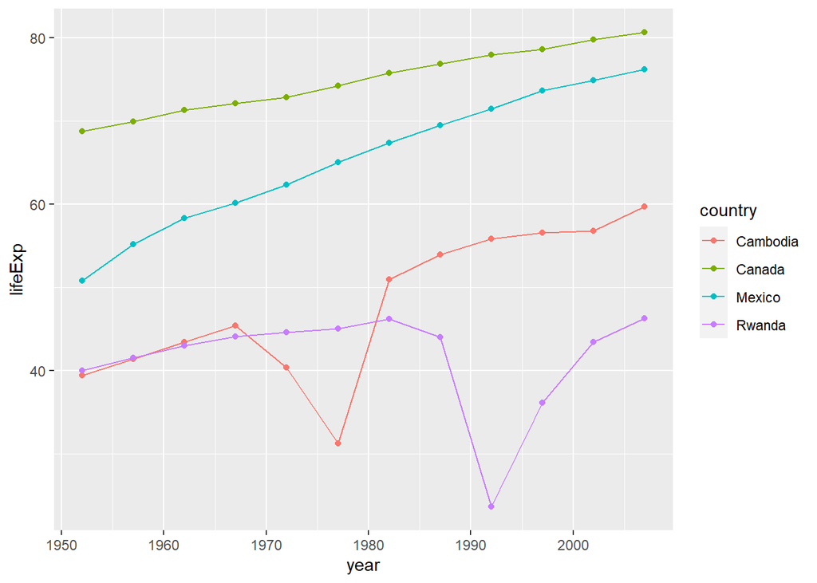

```r
jCountries <- c("Canada", "Rwanda", "Cambodia", "Mexico")

ggplot(subset(gapdata, country %in% jCountries),
       aes(x = year, y = lifeExp, color = country)) +
  geom_line() +
  geom_point()
```

# Saving your **ggplot2** figures

In this section we’ll make a figure and save it to a file. We’ll start by building the figure, then add various elements, including axis labels and a title, and finally save it to a file using `ggsave()`. Note that as we make the figure, we update the `ggplot`` object each time:

Plot life expectancy against GDP with colors by continent

```r
myplot <- ggplot(gapdata, aes(x = gdpPercap, y = lifeExp, color = continent)) + scale_x_log10()

myplot <- myplot +
  geom_point() +
  geom_smooth(method = 'lm')
```

Now add a title and labels:

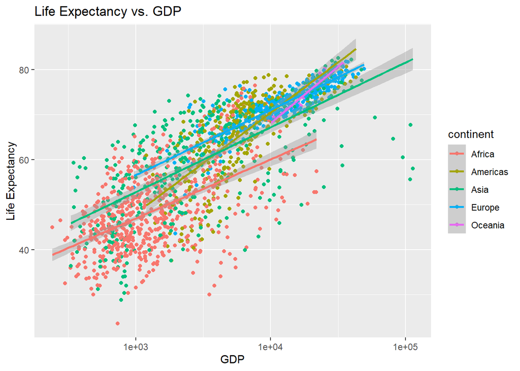

```r
myplot <- myplot +
  ggtitle("Life Expectancy vs. GDP") +
  xlab("GDP") +
  ylab("Life Expectancy")

myplot
```

To save the image, you can dump it directly from the R plot window, but a better way is to use the `ggsave()` function. This provides more control over the final figure. To save as a png:

```r
ggsave("lifeexp_vs_gdp.png", myplot)
```

As a pdf (jpeg, svg, eps also available):

```r
ggsave("lifeexp_vs_gdp.pdf", myplot)
```

To adjust the output size:

```r
ggsave("lifeexp_vs_gdp.png",
       myplot,
       width = 6,
       height = 4)
```

# Themes

**ggplot2** has a default theme with a gray background to the plot. There are a number of included themes that can simply applied to change this. Two of the built in themes are ‘classic’ and ‘bw’:

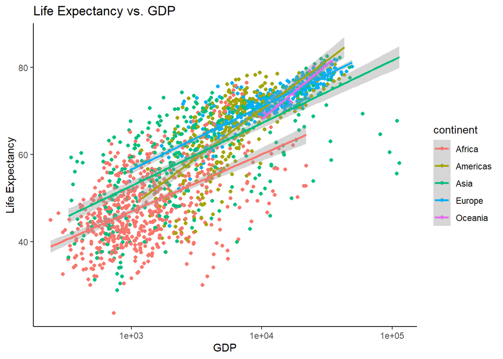

```r
myplot + theme_classic()
```

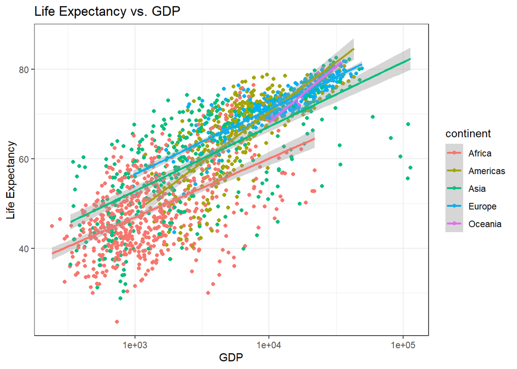

```r
myplot + theme_bw()
```

The add-on package [**ggthemes**](https://yutannihilation.github.io/allYourFigureAreBelongToUs/ggthemes/) includes a number of different themes, including themes inspired by the Economist, the Wall Street Journal and Nate Silver’s blog 538. You will need to install and load this package, for this to work.

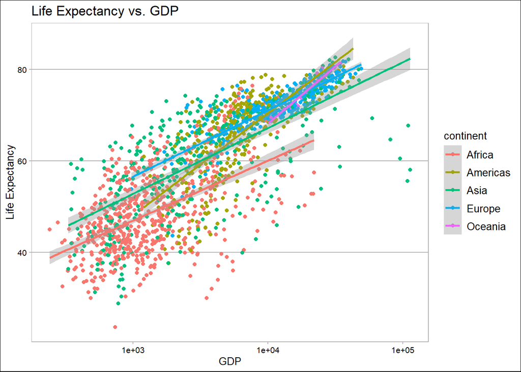

```r
library(ggthemes)

myplot + theme_calc()
```

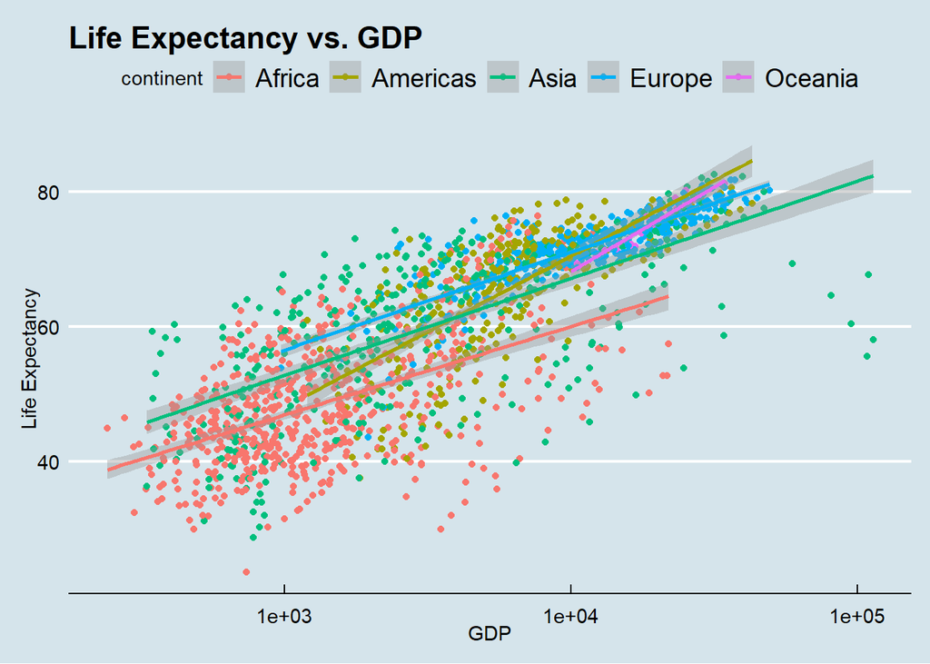

```r
myplot + theme_economist()
```

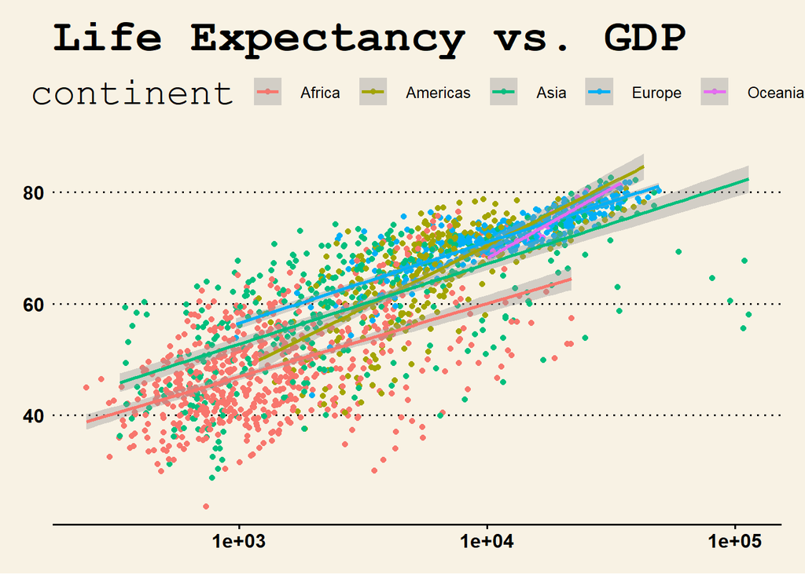

```r
myplot + theme_wsj()
```

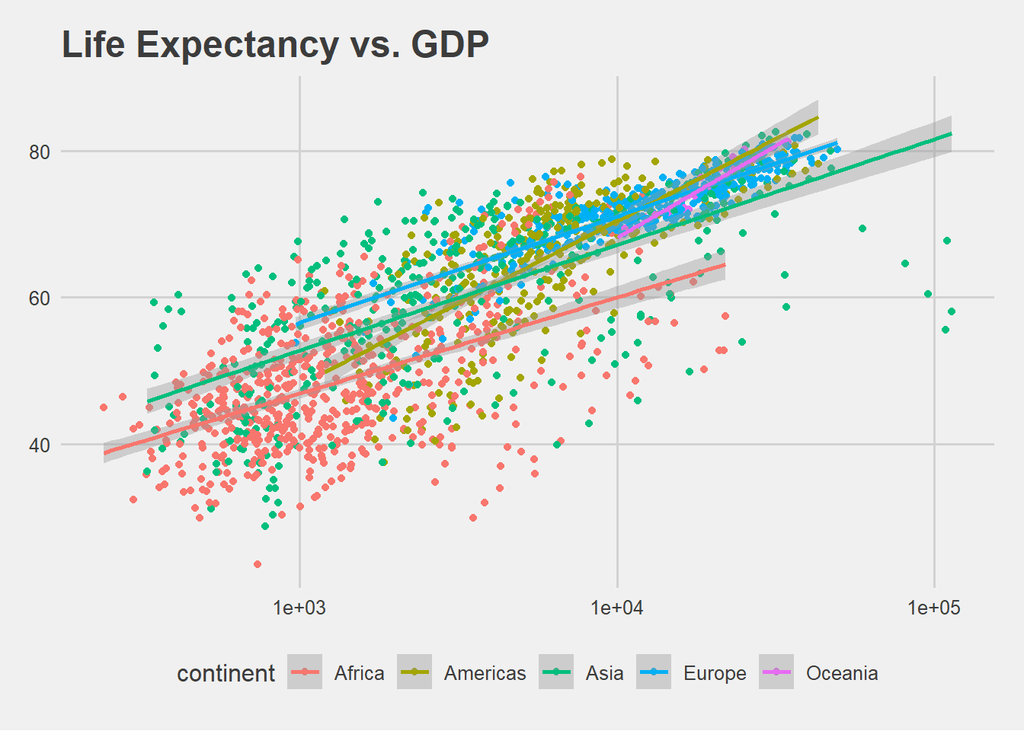

```r
myplot + theme_fivethirtyeight()
```